# meth04_analyze_data

Epigenetics Bootcamp Summer 2024

# Analyze methylation data

Using data preprocessed in our script: meth01_process_data.R

```r
#' we have a processed dataset with 30 samples (otherwise we run script 01)
if(!file.exists("data/processed.rda")){
  source("code/meth01_process_data.R")
}

# load the data
load("data/processed.rda")
```

Load packages

```r
options(warn=-1)
suppressPackageStartupMessages({
  library(DMRcate) # for regional analysis
  library(magrittr)
  library(CpGassoc) # for running association analysis between methylation levels values and phenotype of interest
  library(data.table) # for fast aggregation of large data
  library(qqman) # for visualization of data
  library(stringi) # string manipulation
  library(IlluminaHumanMethylationEPICanno.ilm10b4.hg19)
})
options(warn=0)
```

Code categorical variable as factors

```r
pheno$smoker %<>% factor
pheno$sex    %<>% factor
```

### Cleaning up the methylation data

```r
dim(beta)
```

```
## [1] 865918     30
```

```r
betas.clean = beta[manifest[probe_type=="cg" & !chr %in% c("X","Y")]$index,]
nCpG = dim(betas.clean)[1]
nCpG
```

```
## [1] 843393
```

# Running an Epigenome Wide Association

Here we run an EWAS on Smoking status (as a predictor of methylation)  
First we can run a linear regression on a single CpG that we have already picked

```r
CpG.name = "cg05575921"
pheno$CpG.level <- betas.clean[CpG.name,]
```

Difference in methylation between smokers and non-smokers for this CpG some descriptive statistics

```r
pheno[,.(
   Min    = min   (CpG.level) %>% round(3)
  ,Mean   = mean  (CpG.level) %>% round(3)
  ,Median = median(CpG.level) %>% round(3)
  ,Max    = max   (CpG.level) %>% round(3)
  ,SD     = sd    (CpG.level) %>% round(3)
  ,.N),by=smoker] %>% knitr::kable(.)
```

| smoker | Min | Mean | Median | Max | SD | N |
| --- | --- | --- | --- | --- | --- | --- |
| non-smoker | 0.790 | 0.855 | 0.864 | 0.891 | 0.027 | 15 |
| smoker | 0.376 | 0.467 | 0.464 | 0.565 | 0.066 | 15 |

Difference in beta methylation values between Smokers and non smokers

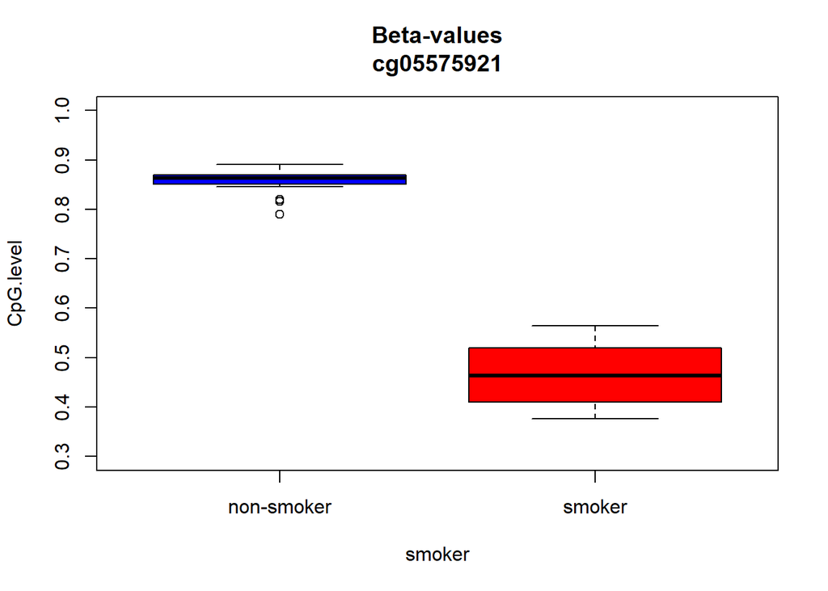

```r
boxplot(CpG.level ~ smoker,pheno,main=paste0("Beta-values\n", CpG.name), col=c("blue","red"),ylim=c(.3,1))
```

Linear regression on betas

```r
lm(CpG.level ~ smoker,data=pheno) %>% summary %>% coef
```

```
##                Estimate Std. Error   t value     Pr(>|t|)
## (Intercept)   0.8548089 0.01300172  65.74584 3.136423e-32
## smokersmoker -0.3881280 0.01838721 -21.10859 9.808768e-19
```

Comparison with m-values

```r
pheno[,CpG.mlevel:=log2(CpG.level/(1-CpG.level))]

pheno[,.(
   Min    = min   (CpG.mlevel) %>% round(3)
  ,Mean   = mean  (CpG.mlevel) %>% round(3)
  ,Median = median(CpG.mlevel) %>% round(3)
  ,Max    = max   (CpG.mlevel) %>% round(3)
  ,SD     = sd    (CpG.mlevel) %>% round(3)
  ,.N),by=smoker] %>% knitr::kable(.)
```

| smoker | Min | Mean | Median | Max | SD | N |
| --- | --- | --- | --- | --- | --- | --- |
| non-smoker | 1.912 | 2.578 | 2.664 | 3.035 | 0.292 | 15 |
| smoker | -0.728 | -0.196 | -0.209 | 0.377 | 0.386 | 15 |

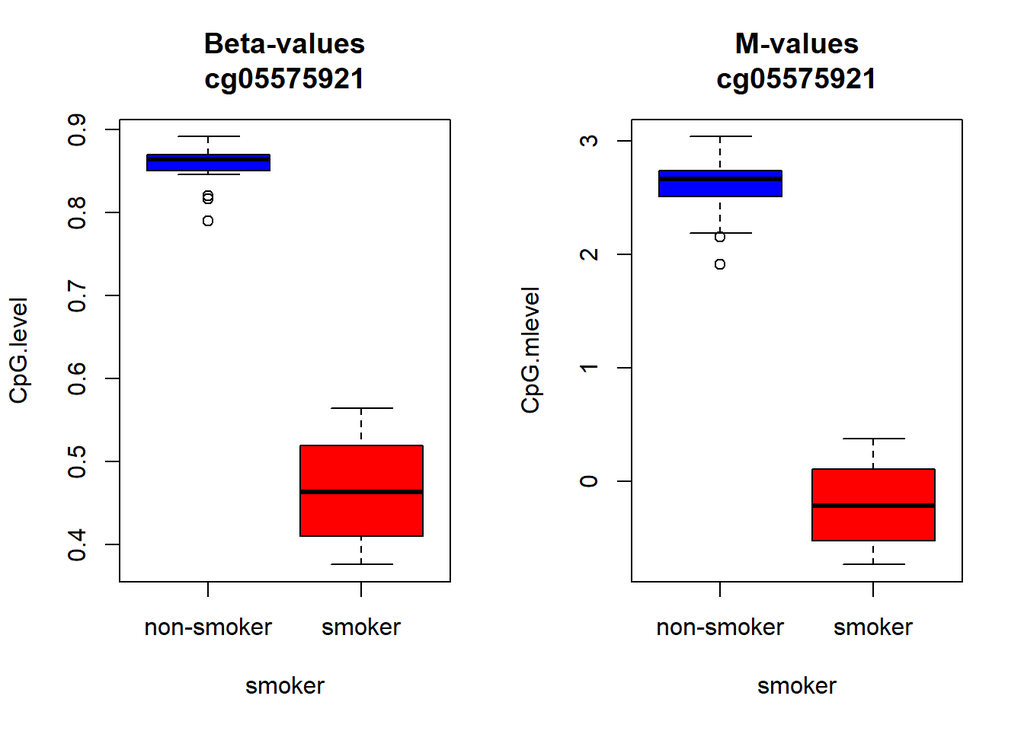

```r
par(mfrow=c(1,2))
boxplot(CpG.level  ~ smoker,data=pheno,main=paste0("Beta-values\n",CpG.name), col=c("blue","red"))
boxplot(CpG.mlevel ~ smoker,data=pheno,main=paste0("M-values\n"   ,CpG.name), col=c("blue","red"))
```

Linear regression on m-values

```r
lm(CpG.mlevel ~ smoker,data=pheno) %>% summary %>% coef
```

```
##               Estimate Std. Error   t value     Pr(>|t|)
## (Intercept)   2.577511 0.08840454  29.15587 1.705643e-22
## smokersmoker -2.773219 0.12502290 -22.18169 2.639544e-19
```

We can always extract measures of the relative quality of statistical models - e.g. adjusted R2 - to look at model performance  
model on betas

```r
lm(CpG.level  ~ smoker,data=pheno) %>% summary %$% adj.r.squared
```

```
## [1] 0.9387633
```

model on mvalues

```r
lm(CpG.mlevel ~ smoker,data=pheno) %>% summary %$% adj.r.squared
```

```
## [1] 0.9442337
```

## EWAS and results using CpGassoc

See [Barfield et al. Bioinformatics 2012](http://www.ncbi.nlm.nih.gov/pubmed/22451269)

Smoking as predictor  
note that CpGassoc is quite fast for running almost a million regressions!

```r
pheno[,smoke_dummy:=ifelse(smoker=="smoker",1,0)]
```

To save some time, we have already run the following cpg.assoc models and are loading the results

```r
load("data/cpg_assoc_results.rda")
```

```r
#system.time(results1 <- cpg.assoc(betas.clean, pheno$smoke_dummy,fdr.cutoff=0.1))
```

there are several components of the results

```r
class(results1)
```

```
## [1] "cpg"
```

```r
names(results1)
```

```
## [1] "results"      "Holm.sig"     "FDR.sig"      "info"         "indep"
## [6] "covariates"   "chip"         "coefficients"
```

Look at a few results  
Here effect size is ~ mean difference in methylation proportion

```r
tail(cbind(results1$coefficients[,4:5], P.value=results1$results[,3]))
```

```
##             effect.size   std.error   P.value
## cg14008164 -0.004581650 0.006492650 0.4862251
## cg04824555 -0.017746414 0.022148454 0.4299830
## cg06066614 -0.012339528 0.018524229 0.5107800
## cg02389671 -0.001777147 0.007741808 0.8201086
## cg23867978 -0.001577212 0.005171942 0.7626554
## cg02366642 -0.044143245 0.029124882 0.1408159
```

and the top hits

```r
head(cbind(results1$coefficients[,4:5],
           P.value=results1$results[,3])[order(results1$results[,3]),])
```

```
##            effect.size  std.error      P.value
## cg05575921  -0.3881280 0.01838721 9.808768e-19
## cg21566642  -0.2636131 0.01611810 7.365949e-16
## cg01940273  -0.1803398 0.01148268 2.057325e-15
## cg03636183  -0.1939379 0.01308397 8.785312e-15
## cg14391737  -0.1915454 0.01450915 1.517969e-13
## cg17087741  -0.1123362 0.01076933 3.760010e-11
```

check with previous result on our selected CpG (running lm without CpGassoc)

```r
cbind(results1$coefficients[,4:5],results1$results[,c(1,3)])[CpG.name,]
```

```
##            effect.size  std.error CPG.Labels      P.value
## cg05575921   -0.388128 0.01838721 cg05575921 9.808768e-19
```

```r
summary(lm(CpG.level~smoker,pheno))
```

```
##
## Call:
## lm(formula = CpG.level ~ smoker, data = pheno)
##
## Residuals:
##       Min        1Q    Median        3Q       Max
## -0.090303 -0.036627  0.007307  0.020743  0.098196
##
## Coefficients:
##              Estimate Std. Error t value Pr(>|t|)
## (Intercept)   0.85481    0.01300   65.75   <2e-16 ***
## smokersmoker -0.38813    0.01839  -21.11   <2e-16 ***
## ---
## Signif. codes:  0 '***' 0.001 '**' 0.01 '*' 0.05 '.' 0.1 ' ' 1
##
## Residual standard error: 0.05036 on 28 degrees of freedom
## Multiple R-squared:  0.9409, Adjusted R-squared:  0.9388
## F-statistic: 445.6 on 1 and 28 DF,  p-value: < 2.2e-16
```

Bonferroni significant hits

```r
table(results1$results[,3] < 0.05/(nCpG))
```

```
##
##  FALSE   TRUE
## 840515     27
```

FDR significant hits

```r
table(results1$results[,5] < 0.05)
```

```
##
##  FALSE   TRUE
## 840458     84
```

EWAS with adjustment for cell types, now we can run the linear regression on betas adjusting for cell proportions. Need sex as indicator in covariate matrix

```r
#results2 = cpg.assoc(
#           betas.clean
#          ,pheno$smoke_dummy
#          ,covariates=as.data.frame(pheno[,.(sex,CD8,CD4,NK,B,MO)])
#          )
```

```r
print(results2)
```

```
##
## The top ten CpG sites were:
##        CPG.Labels T.statistic      P.value Holm.sig          FDR   gc.p.value
## 633177 cg05575921  -18.563433 6.289326e-15     TRUE 5.269235e-09 6.289326e-15
## 407645 cg03636183  -12.872412 1.021084e-11     TRUE 4.277350e-06 1.021084e-11
## 158517 cg14391737  -12.252968 2.660450e-11     TRUE 7.429803e-06 2.660450e-11
## 158491 cg05533761  -11.918798 8.252135e-11     TRUE 1.639711e-05 8.252135e-11
## 489454 cg21566642  -11.346400 1.156430e-10     TRUE 1.639711e-05 1.156430e-10
## 489455 cg01940273  -11.337213 1.174289e-10     TRUE 1.639711e-05 1.174289e-10
## 633200 cg25648203   -8.137955 4.439324e-08     TRUE 5.313275e-03 4.439324e-08
## 489450 cg17087741   -8.018965 5.675587e-08     TRUE 5.862364e-03 5.675587e-08
## 353055 cg17739917   -7.968873 6.297553e-08    FALSE 5.862364e-03 6.297553e-08
## 40105  cg09935388   -7.484205 1.752538e-07    FALSE 1.391768e-02 1.752538e-07
##
## To access results for all  843393  CpG sites use object$results
## or sort(object)$results to obtain results sorted by p-value.
##
## General info:
##   Min.P.Observed Num.Cov fdr.cutoff FDR.method   Phenotype chipinfo num.Holm
## 1   6.289326e-15       6       0.05         BH smoke_dummy     NULL        8
##   num.fdr
## 1      21
##
## 8 sites were found significant by the Holm method
## 21 sites were found significant by BH method
##
## The beta values were taken from: betas.clean
## Effect sizes and standard error can be accessed using $coefficients
## Other attributes are: results, Holm.sig, FDR.sig, info, indep, covariates, chip
##  They can be accessed using the $
```

Using mvalues  
Use of M-values reduces heteroscedasticity to meet linear model assumptions, see [Du P, et al. BMC Bioinformatics. 2010](https://pubmed.ncbi.nlm.nih.gov/21118553/).

```r
#results3 <- cpg.assoc(
#           betas.clean
#          ,pheno$smoke_dummy
#          ,covariates=as.data.frame(pheno[,.(sex,CD8,CD4,NK,B,MO)])
#          ,logit.transform=TRUE
#          )
```

```r
print(results3)
```

```
##
## The top ten CpG sites were:
##        CPG.Labels T.statistic      P.value Holm.sig          FDR   gc.p.value
## 633177 cg05575921  -19.328724 2.716412e-15     TRUE 2.275827e-09 2.716412e-15
## 407645 cg03636183  -12.892025 9.911684e-12     TRUE 4.152034e-06 9.911684e-12
## 158517 cg14391737  -11.990344 4.037536e-11     TRUE 1.127557e-05 4.037536e-11
## 158491 cg05533761  -11.837561 9.358519e-11     TRUE 1.960156e-05 9.358519e-11
## 489454 cg21566642  -11.094065 1.767452e-10     TRUE 2.594071e-05 1.767452e-10
## 489455 cg01940273  -11.064687 1.857760e-10     TRUE 2.594071e-05 1.857760e-10
## 633200 cg25648203   -8.572354 1.839678e-08     TRUE 2.201847e-03 1.839678e-08
## 489450 cg17087741   -8.495175 2.147445e-08     TRUE 2.248927e-03 2.147445e-08
## 353055 cg17739917   -7.931812 6.802654e-08    FALSE 6.332560e-03 6.802654e-08
## 40105  cg09935388   -7.750739 9.943382e-08    FALSE 7.767637e-03 9.943382e-08
##
## To access results for all  843393  CpG sites use object$results
## or sort(object)$results to obtain results sorted by p-value.
##
## General info:
##   Min.P.Observed Num.Cov fdr.cutoff FDR.method   Phenotype chipinfo num.Holm
## 1   2.716412e-15       6       0.05         BH smoke_dummy     NULL        8
##   num.fdr
## 1      18
##
## 8 sites were found significant by the Holm method
## 18 sites were found significant by BH method
##
## The beta values were taken from: betas.clean
## Effect sizes and standard error can be accessed using $coefficients
## Other attributes are: results, Holm.sig, FDR.sig, info, indep, covariates, chip
##  They can be accessed using the $
```

## Genomic inflation in EWAS

qqplot and lambda interpretation

[figure not shown]

```r
par(mfrow=c(1,1))
plot(results1, main="QQ plot for association between methylation and Smoking\nadjusted for cell proportions")
```

[figure not shown]

```r
plot(results2, main="QQ plot for association between (mvals) methylation and Smoking\nadjusted for cell proportions")
```

Lambda - this is a summary measure of genomic inflation  
ratio of observed vs expected median p-value - is there early departure of the qqline estimated at -log10(median=0.5) ~ 0.3 on the x-axis of a qqplot

```r
lambda <- function(p) median(qchisq(p, df=1, lower.tail=FALSE), na.rm=TRUE) / qchisq(0.5, df=1)
```

Lambda before cell type adjustment

```r
lambda(results1$results[,3])
```

```
## [1] 0.8761167
```

Lambda after cell type adjustment

```r
lambda(results2$results[,3])
```

```
## [1] 0.930608
```

```r
datamanhat = cbind(results2$results,results2$coefficients)
setDT(datamanhat)
datamanhat = datamanhat[,.(probe_id=CPG.Labels,effect.size,std.error,P.value)]

datamanhat = merge(datamanhat,manifest[,.(probe_id,chr,mapinfo)],by="probe_id")
```

See where the top hits are

```r
datamanhat[order(P.value)][1:7]
```

```
##      probe_id effect.size  std.error      P.value chr   mapinfo
## 1: cg05575921  -0.3903009 0.02102525 6.289326e-15   5    373378
## 2: cg03636183  -0.2015932 0.01566087 1.021084e-11  19  17000585
## 3: cg14391737  -0.1882402 0.01536282 2.660450e-11  11  86513429
## 4: cg05533761  -0.1284164 0.01077427 8.252135e-11  11  86437953
## 5: cg21566642  -0.2585340 0.02278555 1.156430e-10   2 233284661
## 6: cg01940273  -0.1836955 0.01620288 1.174289e-10   2 233284934
## 7: cg25648203  -0.1149881 0.01412985 4.439324e-08   5    395444
```

Volcano Plot-results2  
Bonferroni threshold

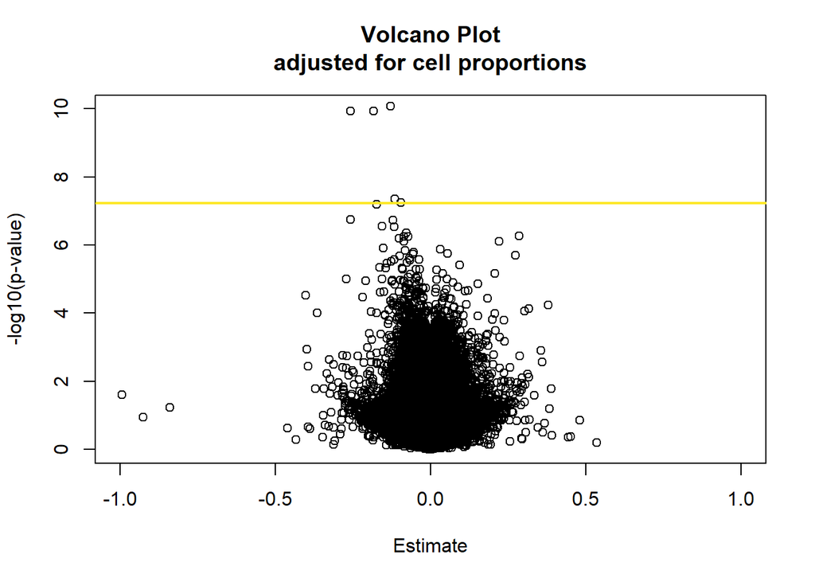

```r
plot(-log10(P.value) ~ effect.size,data=datamanhat,xlab="Estimate",ylab="-log10(p-value)",
     main="Volcano Plot\nadjusted for cell proportions",xlim = c(-1,1),ylim=c(0,10))
abline(h = -log10(0.05/(nCpG)), lty=1, col="#FDE725FF", lwd=2)
```

## Manhattan plot for cell-type adjusted EWAS

Cast the variable chr (so we can simplify and use a numeric x-axis)

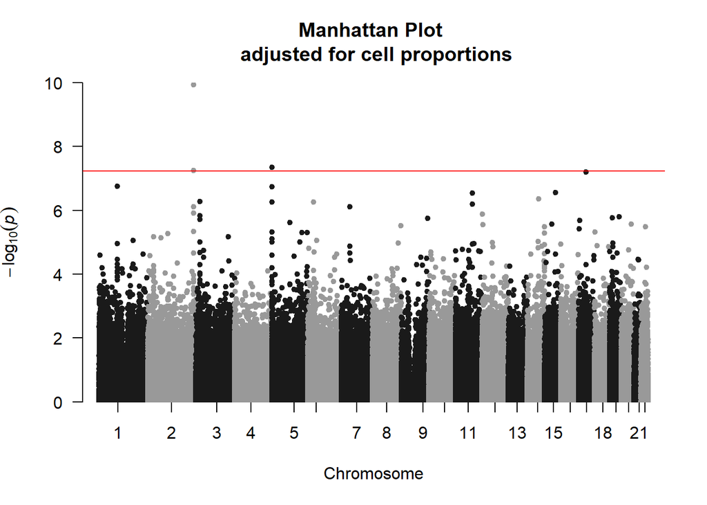

```r
datamanhat[,chr:=as.integer(chr)]

qqman::manhattan(datamanhat,chr="chr",bp="mapinfo",p="P.value",snp="probe_id"
   ,suggestiveline=FALSE, genomewideline = -log10(0.05/(nCpG)),ylim=c(0,10)
   ,main = "Manhattan Plot \n adjusted for cell proportions")
```

# Introduction to limma

see [Smyth GK. Stat Appl Genet Mol Biol 2004](https://www.ncbi.nlm.nih.gov/pubmed/16646809).

```r
suppressMessages(library(limma,minfi))
```

First we need to define a model

```r
model <- model.matrix( ~smoker+sex+CD4+CD8+NK+B+MO,data=pheno)
EWAS.limma <- eBayes(lmFit(betas.clean, design=model))
Top<-topTable(EWAS.limma, coef=2, number=Inf, sort.by="p")[1:10,]
Top
```

```
##                 logFC   AveExpr          t      P.Value    adj.P.Val         B
## cg05575921 -0.3901127 0.6607449 -19.160646 6.292443e-16 5.290730e-10 26.519140
## cg03636183 -0.2028285 0.5556629 -13.474104 1.333692e-12 5.606890e-07 18.928434
## cg14391737 -0.1883914 0.2986025 -12.603206 5.391963e-12 1.511200e-06 17.525451
## cg05533761 -0.1288225 0.4735094 -12.199579 1.900466e-11 3.309721e-06 16.300970
## cg21566642 -0.2577281 0.4655840 -11.738692 2.322583e-11 3.309721e-06 16.054769
## cg01940273 -0.1843502 0.5210231 -11.729034 2.361817e-11 3.309721e-06 16.037878
## cg25648203 -0.1154925 0.7028751  -8.453492 1.297044e-08 1.557948e-03  9.656271
## cg17087741 -0.0958348 0.7943528  -8.329013 1.692968e-08 1.779324e-03  9.386365
## cg17739917 -0.1743542 0.3379400  -8.208887 2.193542e-08 2.049272e-03  9.123925
## cg18110140 -0.1580193 0.4137623  -7.867121 4.632081e-08 3.894686e-03  8.366710
```

Bind results with annotation

```r
Annot<-as.data.frame(getAnnotation(IlluminaHumanMethylationEPICanno.ilm10b4.hg19))
Annot.Tops<- Annot[match(rownames(Top),Annot$Name),]
Annot.Tops<-Annot.Tops[,c("UCSC_RefGene_Name","UCSC_RefGene_Group","Relation_to_Island","chr","pos")]
Top<-cbind(Top[,1:5], Annot.Tops)
```

Order by chr and chromosomal position

```r
Top$chr = as.numeric(gsub("chr", "", Top$chr))
Top[order(Top$chr,Top$pos),c(1,6,7,8,9,10)]
```

```
##                 logFC                                UCSC_RefGene_Name
## cg17087741 -0.0958348
## cg21566642 -0.2577281
## cg01940273 -0.1843502
## cg05575921 -0.3901127                                             AHRR
## cg25648203 -0.1154925                                             AHRR
## cg05533761 -0.1288225
## cg14391737 -0.1883914 PRSS23;PRSS23;PRSS23;PRSS23;PRSS23;PRSS23;PRSS23
## cg18110140 -0.1580193
## cg17739917 -0.1743542                                   RARA;RARA;RARA
## cg03636183 -0.2028285                                            F2RL3
##                              UCSC_RefGene_Group Relation_to_Island chr
## cg17087741                                                 N_Shore   2
## cg21566642                                                  Island   2
## cg01940273                                                  Island   2
## cg05575921                                 Body            N_Shore   5
## cg25648203                                 Body            OpenSea   5
## cg05533761                                                 OpenSea  11
## cg14391737 5'UTR;Body;Body;5'UTR;Body;Body;Body            S_Shore  11
## cg18110140                                                 OpenSea  15
## cg17739917                    5'UTR;5'UTR;5'UTR            S_Shelf  17
## cg03636183                                 Body            N_Shore  19
##                  pos
## cg17087741 233283010
## cg21566642 233284661
## cg01940273 233284934
## cg05575921    373378
## cg25648203    395444
## cg05533761  86437953
## cg14391737  86513429
## cg18110140  75350380
## cg17739917  38477572
## cg03636183  17000585
```

End of script 04